# Loan Data from Prosper by SHIVANAND

# Multivariate Plots Section

```
## [1] "EstimatedReturn vs LoanOriginalAmount vs ProsperScore"
```

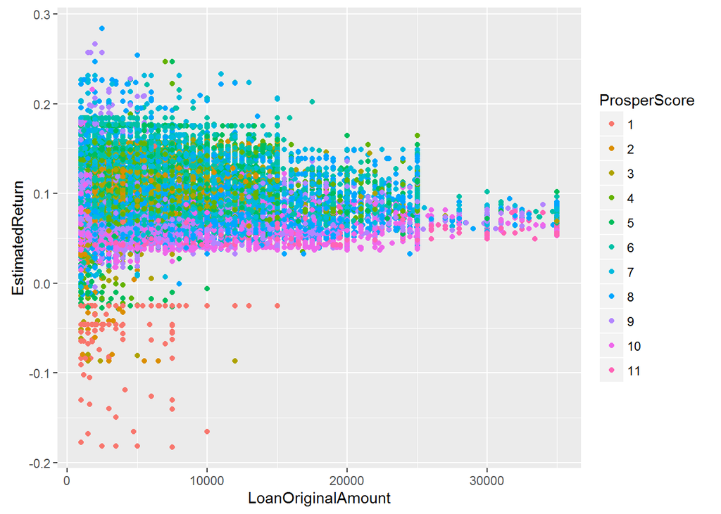

```
## [1] "The variance is very high and the distribution is not very clear, instead faceting by ProsperScore"
```

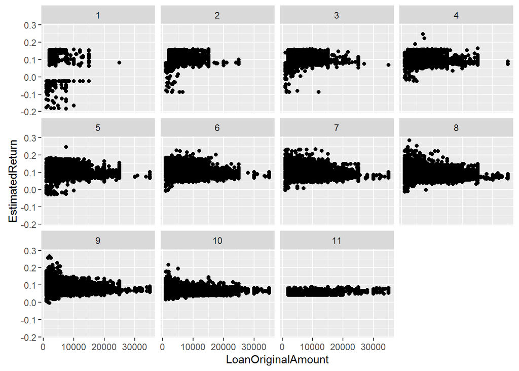

[output not shown]

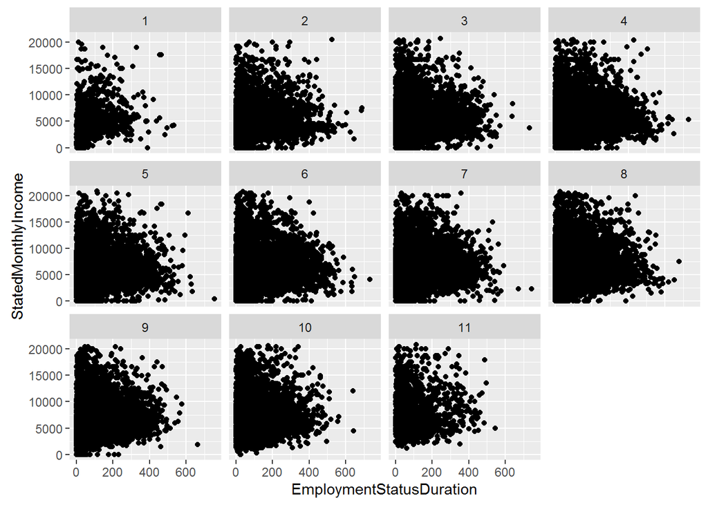

```
## [1] "Variance is very High. Can not draw any strong hypothesis from above"
```

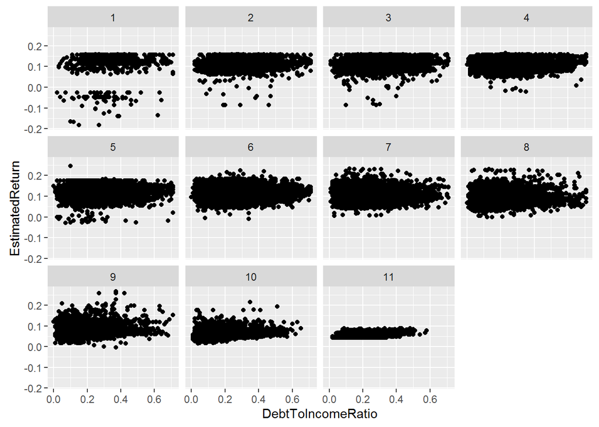

```
## [1] "Again the variance is very high to make solid hypothesis"
```

```
## [1] "ListingCreationDate vs MeanProsperScore faceted by Loan Status. This is done to see the how the MeanProspoerScore evolved over time for each LoanStatus"
```

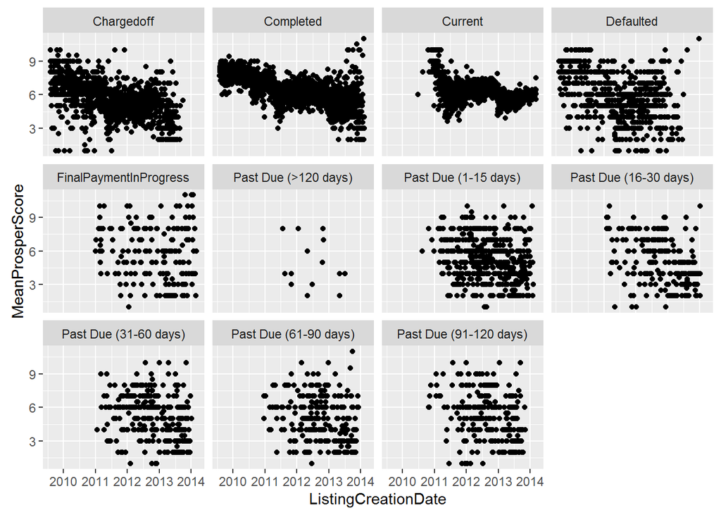

```
## [1] "The variance of MeanProsperScore for Current LoanStatus is the least. However, the variance of MeanProsperScore across every other LoanStatus is still very high."
```

# Multivariate Analysis

### Were there any interesting or surprising interactions between features?

##### We could hypothesize new Strategy of Prosper Investors by observing the plot of Evolution of MeanProsperScore since 2009, across different LoanStatus. For current Loans the variance of MeanProsperScore is the least among all LoanStatus. One hypothesis could be Investors have taken a new decision to give more weightage to ProsperScore, and mainly selecting Loans from middle of the ProsperScore Distribution

### OPTIONAL: Did you create any models with your dataset? Discuss the strengths and limitations of your model.

# Final Plots and Summary

### Plot One

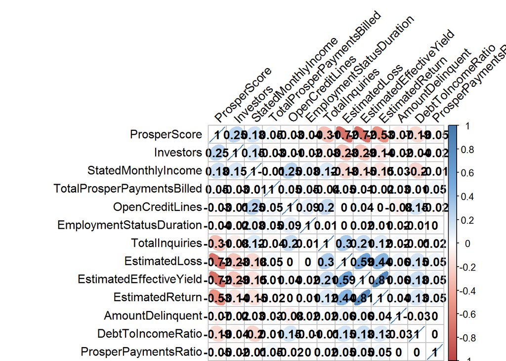

### Description One

#### It is a correlationplot among all the numeric and int variables. Also converted ProsperScore to numeric just for this plot. ProsperScore has negative correlation with EstimatedEffectiveYeild, EstimatedLoss and EstimatedReturn. Has weak correlation with TotalInquiries and DebtToIncomeRatio and has weak positive correlation with Investors. Surprisingly we did not observe any significant correlations among other variables except for EstimatedReturn, EstimatedEffectiveYield and EstimatedLoss.

### Plot Two

```
## [1] "EstimatedReturn vs LoanOriginalAmount vs ProsperScore"
```

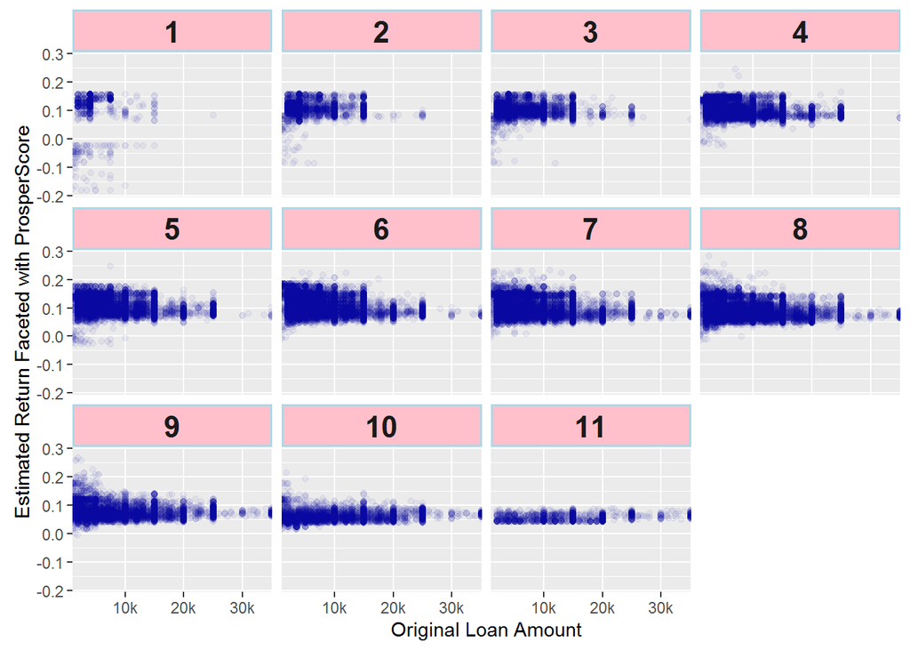

### Description Two

#### We can see in plots where ProsperScore = 1, 2 and 3 LoanOriginalAmount is less and as the ProsperScore increases Loan Amount increases. Also, The variance seems to follow a normal distribution from ProsperScore 2 to 11.

### Plot Three

```
## [1] "ListingCreationDate vs MeanProsperScore faceted by Loan Status"
```

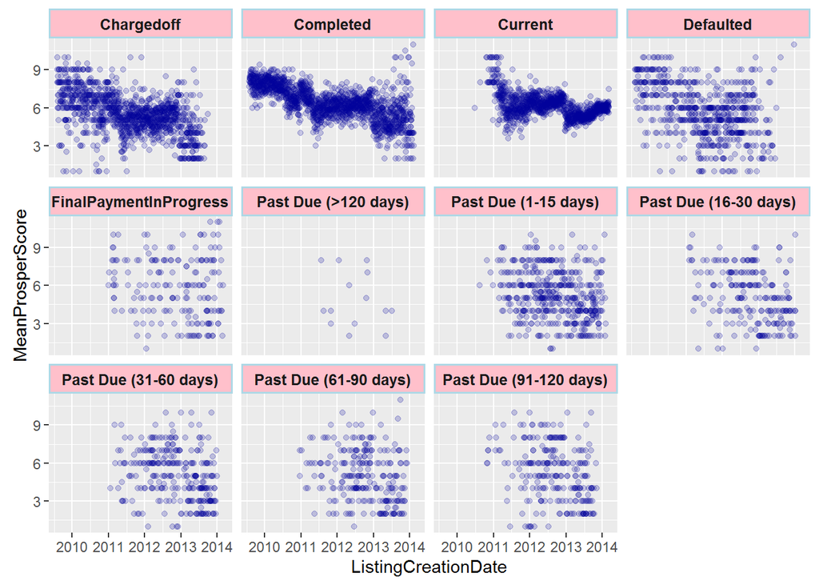

# Reflection

##### Certainly not an easy project to start off, there were 81 variables, to understand what each variable meant, and then to shrink the list to 18 variables took some time. I thought from an Investor perspective to see what parameters give a strong correlation to Estimatedreturn, and what are the different customer profiles with defaulted/chargedoff and Completed Loanstatus.

##### It was a good learning experince as initially, I had seen a lot of dead ends, mainly as I could not find strong correlations to explore further. Then I decided to see the distributions across categorical variables, this approach gave me better picture of how the variables of interest (EstimatedReturn and LoanStatus)vary across multiple variables.

##### Further I would like to test the hypothesis,of the new strategy of Investors to select loans with averageProsperScore in a small range as was observed in the MainPlot3.

##### There is so much more that could be done, firstly testing all the variables and then choosing the best ones from them. Second, a classification model based on customer profile to test whether a particular listing will be defaulted/Chargedoff. Third, would be to better understand why there is a difference between EstimatedReturn given in the dataset with EstimatedReturnCalc (EstimatedEffectiveYield - EstimatedLoss)